# DS 2003 Midterm Project

Ben Alter, Ryan Gunn, Samuel Rea, Kayla Sprincis, Pallavi Vemuri

## Our Data Set

- The data set being used is a set of 2023 LinkedIn Job Postings.
- Sourced from https://www.kaggle.com/datasets/arshkon/linkedin-job-postings
- Created by Arsh Kon
- 27 columns with information spaning from published date to job descriptions

## Data Cleaning Process

Importing and Removing Unnecessary/Unusable Columns

```r
#packages used
library(dplyr)
library(tidyr)
library(ggplot2)
library(RColorBrewer)
library(usmap)
library(mapproj)
library(maps)

jobs <- read.csv('job_postings.csv')

#remove unnecessary columns (most had many NAs)
jobs <- jobs[-c(1,2,12,15,16,18:27)]

#Create avg_year_pay column (update the hourly to be for a year of a 40hr work week)
jobs <- jobs%>%
  mutate(avg_year_pay = ifelse(pay_period=='HOURLY', rowMeans(jobs[,3:5], na.rm = T) * 2080,rowMeans(jobs[,3:5], na.rm = T)))

#remove rows without pay details
jobs <- jobs %>% drop_na(avg_year_pay)

#put true and false in for remote_allowed
jobs <- jobs %>%
  mutate(remote_allowed = ifelse(is.na(remote_allowed), F, T))

#extract state variable
jobs$state <- sub('.*, ', '', jobs$location)

jobs <- jobs %>%
  mutate(state = ifelse(nchar(state)> 2, NA, state))

#Final NA removals
jobs <- subset(jobs, select = -c(max_salary, med_salary, min_salary))
jobs <- jobs %>% drop_na(applies, views, state)
```

## Columns of Cleaned Data Set

- title
- description
- pay_period
- formatted_work_type
- location
- applies
- remote_allowed
- views
- application_type
- avg_year_pay
- state

## Summaries of important variables

Number of jobs:

```r
nrow(jobs)
```

```
## [1] 3102
```

avg_year_pay: Average (of max, med, and min) salary of yearly jobs and hourly adjusted to be 40 hours a week for a year

```r
summary(jobs['avg_year_pay'])
```

```
##   avg_year_pay
##  Min.   :    13.5
##  1st Qu.: 57500.0
##  Median : 87500.0
##  Mean   : 99660.4
##  3rd Qu.:129200.0
##  Max.   :998426.0
```

formatted_work_type: The time commitment of a job

```r
table(jobs['formatted_work_type'])
```

```
## formatted_work_type
##   Contract  Full-time Internship      Other  Part-time  Temporary
##        383       2572         20         13         94         20
```

state: What state the job is located in

```r
table(jobs['state'])
```

```
## state
##  AK  AL  AR  AZ  CA  CO  CT  DC  DE  FL  GA  HI  IA  ID  IL  IN  KS  KY  LA  MA
##   3  15  10  61 827 100  33  39   3 136 100   5  11  13 112  26  10  11   9  91
##  MD  ME  MI  MN  MO  MS  MT  NC  ND  NE  NH  NJ  NM  NV  NY  OH  OK  OR  PA  RI
##  60   2  49  38  30   5   2  68   4   9   3  97   6  12 314  57  13  24  68  10
##  SC  SD  TN  TX  UT  VA  WA  WI  WV  WY
##  29   1  41 215  30 101 165  32   1   1
```

remote_allowed: If a person is able to work remotely

```r
table(jobs['remote_allowed'])
```

```
## remote_allowed
## FALSE  TRUE
##  2846   256
```

applies: How many applications a certain job has gotten

```r
summary(jobs['applies'])
```

```
##     applies
##  Min.   :  1.0
##  1st Qu.:  2.0
##  Median :  6.0
##  Mean   : 17.2
##  3rd Qu.: 17.0
##  Max.   :368.0
```

views: How many views the job has gotten on LinkedIn

```r
summary(jobs['views'])
```

```
##      views
##  Min.   :   1.00
##  1st Qu.:  18.00
##  Median :  43.50
##  Mean   :  80.73
##  3rd Qu.:  94.75
##  Max.   :1223.00
```

## Data Question 1: Does the number of submitted applications change based on application type?

Examining the data for specific trends before building graph and making the data proportional because of the lack of similar numbers of each type of application type.

```r
app_type<-unique(jobs$application_type)
table(jobs$application_type)
```

```
##
## ComplexOnsiteApply       OffsiteApply  SimpleOnsiteApply
##               1466               1499                137
```

```r
#making the data proportional/ count of applications for each type
count_app <- jobs %>%
  group_by(application_type) %>%
  summarize(TotalApplications = sum(applies))
#count of total number of observations by application type
count_type<-jobs%>%
  count(factor(application_type))
count_type<-count_type%>%
  rename("application_type"="factor(application_type)")
#now that we have the total number of applies for each job we can multiply that by the (total number of observations for each application type)
#now making a new data set that we can then put into a bar graph and get some interesting results
final_data<-inner_join(count_app,count_type,by="application_type")
final_data$prop_app<-(final_data$TotalApplications/final_data$n)
```

Building a graph with the number of submitted applications based on application type

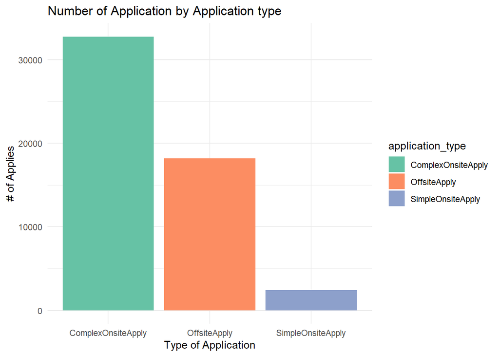

```r
colors<-brewer.pal(4,"Set2")
ggplot(data=jobs,aes(x=application_type,y=applies,fill=application_type))+geom_bar(stat = "identity")+labs(title = "Number of Application by Application type",x="Type of Application",y="# of Applies")+scale_fill_manual(values = colors)+theme_minimal()
```

A graph that looks at this data proportionally based off observations so basically this is a graph of the number of applications per job listing grouped by the application type.

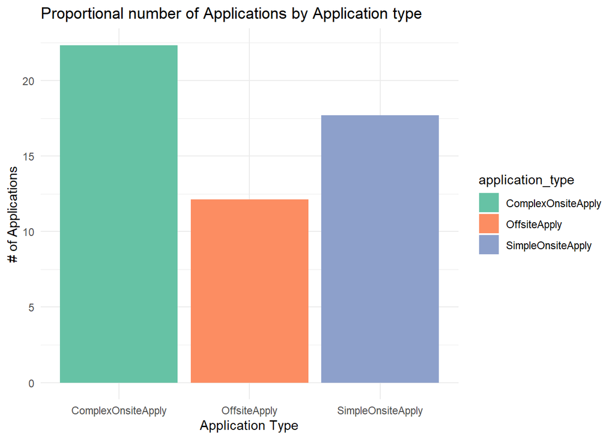

```r
ggplot(final_data,aes(x=application_type,y=prop_app,fill=application_type))+geom_bar(stat = "identity")+labs(title = "Proportional number of Applications by Application type",x="Application Type",y="# of Applications")+theme_minimal()+scale_fill_manual(values = colors)
```

## Data Question 2: How does salary change on average for remote vs. in person?

Summary of salaries of job that allow remote work Highest salary remote careers: tech managers in fintech, product managers, AI engineers

```r
df <- subset(jobs,select=c('title','remote_allowed','avg_year_pay'))
df <- df[(df$remote_allowed %in% TRUE ),]
df <- df[order(df$avg_year_pay,decreasing=TRUE),]
summary(df$avg_year_pay)
```

```
##    Min. 1st Qu.  Median    Mean 3rd Qu.    Max.
##      35   70720  105000  118110  142700  875000
```

Summary of salaries of jobs that require in person work Highest salary in-person careers: quantitative developer, criminal court clerk, head of healthcare sales, doctors (urologists and psychiatrists)

```r
df <- subset(jobs,select=c('title','remote_allowed','avg_year_pay'))
df <- df[(df$remote_allowed %in% FALSE ),]
df <- df[order(df$avg_year_pay,decreasing=TRUE),]
summary(df$avg_year_pay)
```

```
##     Min.  1st Qu.   Median     Mean  3rd Qu.     Max.
##     13.5  57200.0  85000.0  98000.9 127120.0 998426.0
```

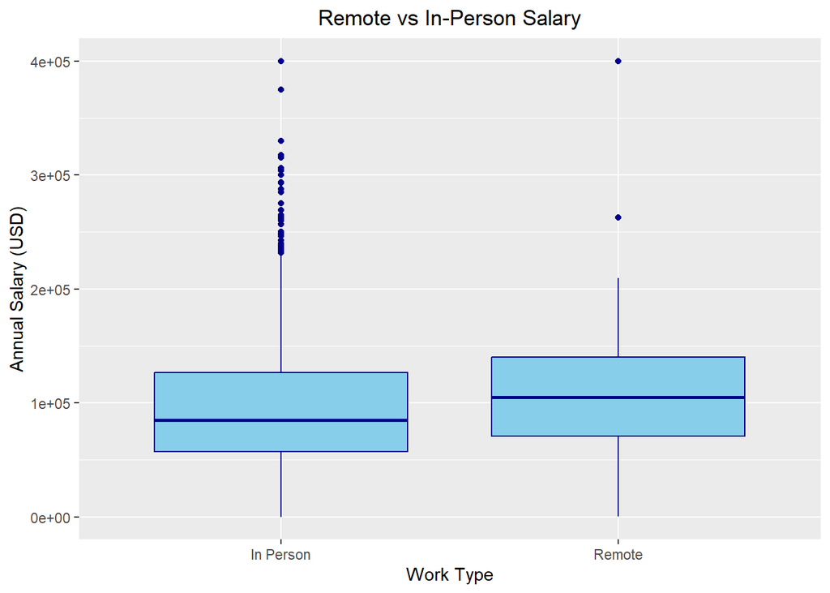

```r
ggplot(data = jobs, aes(x=remote_allowed, y=avg_year_pay)) +
    geom_boxplot(color = "darkblue", fill = "skyblue") +
    labs(title='Remote vs In-Person Salary',y='Annual Salary (USD)',x='Work Type')+theme(plot.title = element_text(hjust = 0.5),legend.position = "None")+
    scale_x_discrete(labels = c("In Person", "Remote"))+ ylim(0,400000)
```

Data Question 3: On average which states/locations are offering higher paying jobs?

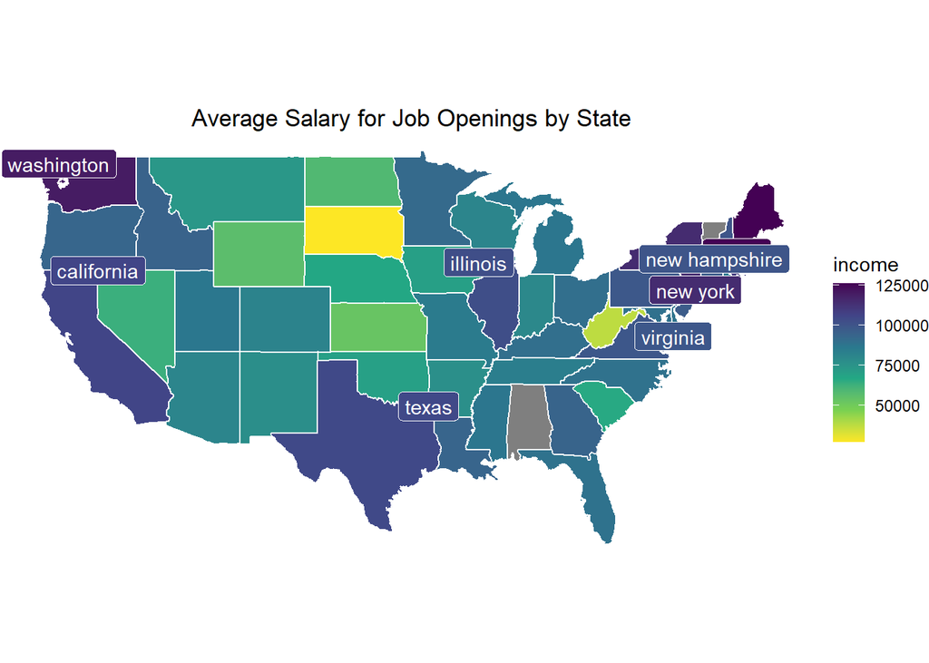

```r
#reading jobpostings dataset + removing NA's
df= jobs

#finding the average salary by state
dataset = as.data.frame.list(tapply(df$avg_year_pay,df$state,mean))
df2 = data.frame(t(dataset[,-1]))
colnames(df2) = c("income")

#merging US and df2

df2$region = c("clabama", "arkansas", "arizona", "california", "colorado", "connecticut", "district of columbia", "delaware", "florida", "georgia", "hawaii", "iowa", "idaho", "illinois", "indiana", "kansas", "kentucky", "louisiana", "massachusetts", "maryland", "maine", "michigan", "minnesota", "missouri", "mississippi", "montana", "north carolina", "north dakota", "nebraska", "new hampshire", "new jersey", "new mexico", "nevada", "new york", "ohio", "oklahoma", "oregon", "pennsylvania", "rhode island", "south carolina", "south dakota", "tennessee", "texas", "utah", "virginia", "washington", "wisconsin", "west virginia", "wyoming")

US<-map_data("state")
mergermoment = US %>% full_join(df2)
#plotting

ggplot(mergermoment, aes(long, lat, group=group,fill=income))+geom_polygon(color="white")+coord_quickmap()+scale_fill_viridis_c(option = "viridis", direction = -1)+geom_label(data=filter(distinct(mergermoment, region,.keep_all = TRUE),region %in% c("washington", "california", "texas","illinois","virginia", "new york", "maine", "new hampshire")), aes(label=region), color = "white")+theme_classic()+theme_void()+ ggtitle("Average Salary for Job Openings by State") + theme(plot.title = element_text(hjust = 0.5))
```

## Data Question 4: Which common skills are associated with higher paying jobs?

Step 1- Identify Skills to test Top 5 Skills: Communication Skills, Problem-Solving, Teamwork, Technical Skills, Analytical Skills

```r
LinkedIn = jobs

# Phrase to search for
phrase_to_find = "communication skills"

# Check if the phrase is in the description
has_communication_skills = grepl(phrase_to_find, LinkedIn$description, ignore.case = TRUE)

# Create a new dataset for profiles with "communication skills"
communication_data = subset(LinkedIn, has_communication_skills)

phrase_to_find2 = "problem-solving"
has_problemsolving = grepl(phrase_to_find2, LinkedIn$description, ignore.case = TRUE)
psolving_data = subset(LinkedIn, has_problemsolving)

phrase_to_find3 = "teamwork"
has_teamwork = grepl(phrase_to_find3, LinkedIn$description, ignore.case = TRUE)
teamwork_data = subset(LinkedIn, has_teamwork)

phrase_to_find4 = "analytical skills"
has_analytics = grepl(phrase_to_find4, LinkedIn$description, ignore.case = TRUE)
analytics_data = subset(LinkedIn, has_analytics)

phrase_to_find5 = "technical skills"
has_tech = grepl(phrase_to_find5, LinkedIn$description, ignore.case = TRUE)
tech_data = subset(LinkedIn, has_tech)
```

Step 2 - 1 dataframe with all the salaries from the other subsets. Use avg_year_pay as the salary for consistency.

```r
# Load the ggplot2 library if not already loaded
library(ggplot2)

# Create a combined data frame for the skills and their corresponding labels
byskill_data <- rbind(
  data.frame(Skill = "Communication", Salary = communication_data$avg_year_pay),
  data.frame(Skill = "Problem Solving", Salary = psolving_data$avg_year_pay),
  data.frame(Skill = "Teamwork", Salary = teamwork_data$avg_year_pay),
  data.frame(Skill = "Analytical", Salary = analytics_data$avg_year_pay),
  data.frame(Skill = "Technical", Salary = tech_data$avg_year_pay)
)
```

Visualization 1: Boxplot

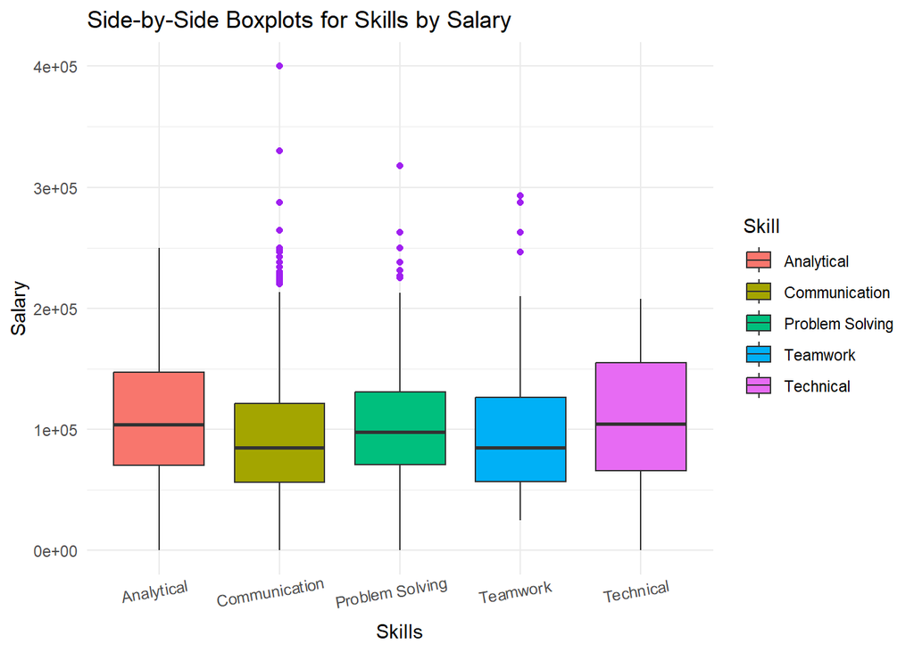

```r
# Create a side-by-side boxplot
ggplot(byskill_data, aes(x = Skill, y = Salary, fill = Skill)) +
  geom_boxplot(outlier.color = "purple") +
  labs(title = "Side-by-Side Boxplots for Skills by Salary", x = "Skills", y = "Salary") +
  theme_minimal() +
  theme(axis.text.x = element_text(angle = 10, hjust = .6)) + coord_cartesian(ylim = c(0, 400000))
```

Visualization 2: Histogram- This shows how many more jobs ask for communication skills at every salary level.

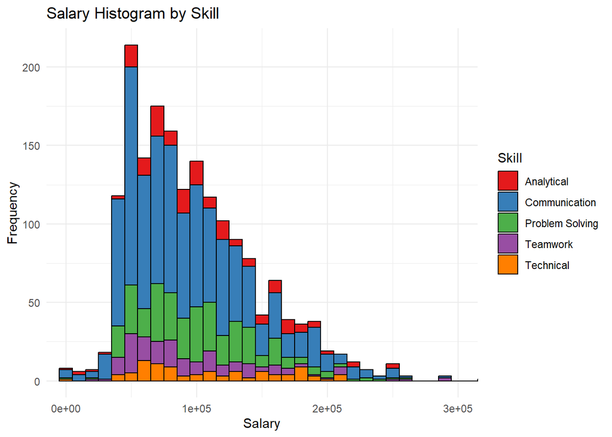

```r
ggplot(byskill_data, aes(x = Salary, fill = Skill)) +
  geom_histogram(binwidth = 10000, color = "black") +
  labs(title = "Salary Histogram by Skill", x = "Salary", y = "Frequency") +
  scale_fill_brewer(palette = "Set1") +
  theme_minimal() + coord_cartesian(xlim = c(0, 300000))
```

Visualization 3= Violin Plot

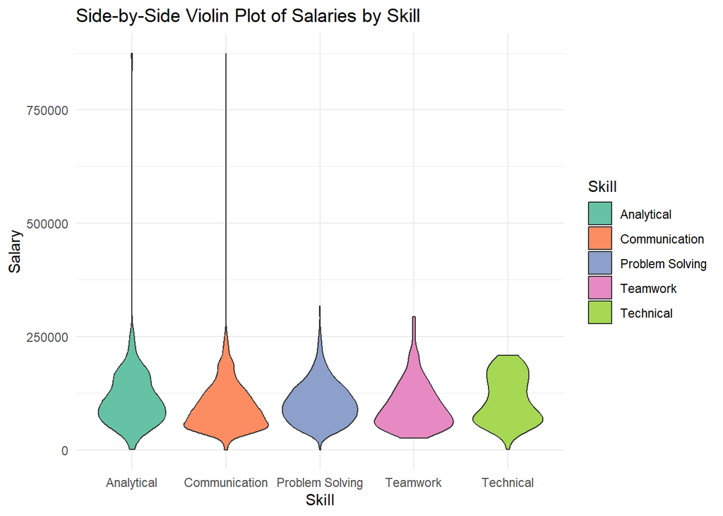

```r
ggplot(byskill_data, aes(x = Skill, y = Salary, fill = Skill)) +
  geom_violin() +
  labs(title = "Side-by-Side Violin Plot of Salaries by Skill", x = "Skill", y = "Salary") +
  scale_fill_brewer(palette = "Set2") +
  theme_minimal()
```